# hwk_7

perform marginal tests compare pairs of models using anova() - for each term to test, compare a model with this term to model without this term

```r
# no temp.factor
model_no_temp <- glmmTMB(
  total.prey ~ predators + temp.factor*predators,
  family = nbinom2,
  data = bugs
)
summary(model_no_temp) # nothing sig
```

```
##  Family: nbinom2  ( log )
## Formula:          total.prey ~ predators + temp.factor * predators
## Data: bugs
##
##       AIC       BIC    logLik -2*log(L)  df.resid
##     734.5     761.7    -354.2     708.5        47
##
##
## Dispersion parameter for nbinom2 family (): 0.188
##
## Conditional model:
##                                 Estimate Std. Error z value Pr(>|z|)
## (Intercept)                      5.69440    1.03150   5.520 3.38e-08 ***
## predatorsHA+HM                   0.63890    1.45867   0.438    0.661
## predatorsHM                      0.33289    1.45870   0.228    0.819
## predatorsnone                    0.25936    1.45872   0.178    0.859
## temp.factor17_20                 0.61436    1.45864   0.421    0.674
## temp.factor22_25                 0.04023    1.45876   0.028    0.978
## predatorsHA+HM:temp.factor17_20 -0.91071    2.06281  -0.441    0.659
## predatorsHM:temp.factor17_20    -1.08947    2.06290  -0.528    0.597
## predatorsnone:temp.factor17_20   0.69425    2.06276   0.337    0.736
## predatorsHA+HM:temp.factor22_25 -0.63180    2.06293  -0.306    0.759
## predatorsHM:temp.factor22_25    -1.67560    2.06338  -0.812    0.417
## predatorsnone:temp.factor22_25   0.68512    2.06287   0.332    0.740
## ---
## Signif. codes:  0 '***' 0.001 '**' 0.01 '*' 0.05 '.' 0.1 ' ' 1
```

```r
# no predators
model_no_pred <- glmmTMB(
  total.prey ~ temp.factor + temp.factor*predators,
  family = nbinom2,
  data = bugs
)
summary(model_no_pred) # nothing sig
```

```
##  Family: nbinom2  ( log )
## Formula:          total.prey ~ temp.factor + temp.factor * predators
## Data: bugs
##
##       AIC       BIC    logLik -2*log(L)  df.resid
##     734.5     761.7    -354.2     708.5        47
##
##
## Dispersion parameter for nbinom2 family (): 0.188
##
## Conditional model:
##                                 Estimate Std. Error z value Pr(>|z|)
## (Intercept)                      5.69440    1.03150   5.520 3.38e-08 ***
## temp.factor17_20                 0.61436    1.45864   0.421    0.674
## temp.factor22_25                 0.04023    1.45876   0.028    0.978
## predatorsHA+HM                   0.63890    1.45867   0.438    0.661
## predatorsHM                      0.33289    1.45870   0.228    0.819
## predatorsnone                    0.25936    1.45872   0.178    0.859
## temp.factor17_20:predatorsHA+HM -0.91071    2.06281  -0.441    0.659
## temp.factor22_25:predatorsHA+HM -0.63180    2.06293  -0.306    0.759
## temp.factor17_20:predatorsHM    -1.08947    2.06290  -0.528    0.597
## temp.factor22_25:predatorsHM    -1.67560    2.06338  -0.812    0.417
## temp.factor17_20:predatorsnone   0.69425    2.06276   0.337    0.736
## temp.factor22_25:predatorsnone   0.68512    2.06287   0.332    0.740
## ---
## Signif. codes:  0 '***' 0.001 '**' 0.01 '*' 0.05 '.' 0.1 ' ' 1
```

```r
# no interaction
model_no_int <- glmmTMB(
  total.prey ~ predators + temp.factor,
  family = nbinom2,
  data = bugs
)
summary(model_no_int) # nothing sig
```

```
##  Family: nbinom2  ( log )
## Formula:          total.prey ~ predators + temp.factor
## Data: bugs
##
##       AIC       BIC    logLik -2*log(L)  df.resid
##     724.1     738.7    -355.0     710.1        53
##
##
## Dispersion parameter for nbinom2 family (): 0.183
##
## Conditional model:
##                  Estimate Std. Error z value Pr(>|z|)
## (Intercept)        6.0174     0.7935   7.584 3.36e-14 ***
## predatorsHA+HM     0.1222     0.8611   0.142    0.887
## predatorsHM       -0.4906     0.8804  -0.557    0.577
## predatorsnone      0.8208     0.8563   0.959    0.338
## temp.factor17_20   0.1813     0.7686   0.236    0.814
## temp.factor22_25  -0.4307     0.7790  -0.553    0.580
## ---
## Signif. codes:  0 '***' 0.001 '**' 0.01 '*' 0.05 '.' 0.1 ' ' 1
```

run comparisons between candidate models using anova

```r
# not sure how to address interaction, seems important to compare against full
anova(model_full, model_no_temp) # wow! removing temp sig increases model fit compared to full
```

```
## Data: bugs
## Models:
## model_full: total.prey ~ temp.factor + predators + temp.factor * predators, zi=~0, disp=~1
## model_no_temp: total.prey ~ predators + temp.factor * predators, zi=~0, disp=~1
##               Df   AIC   BIC   logLik deviance Chisq Chi Df Pr(>Chisq)
## model_full    12 34028 34053 -17002.0    34004
## model_no_temp 13   734   762   -354.2      708 33296      1  < 2.2e-16 ***
## ---
## Signif. codes:  0 '***' 0.001 '**' 0.01 '*' 0.05 '.' 0.1 ' ' 1
```

```r
anova(model_full, model_no_pred) # wow! removing pred sig increases model fit compared to full
```

```
## Data: bugs
## Models:
## model_full: total.prey ~ temp.factor + predators + temp.factor * predators, zi=~0, disp=~1
## model_no_pred: total.prey ~ temp.factor + temp.factor * predators, zi=~0, disp=~1
##               Df   AIC   BIC   logLik deviance Chisq Chi Df Pr(>Chisq)
## model_full    12 34028 34053 -17002.0    34004
## model_no_pred 13   734   762   -354.2      708 33296      1  < 2.2e-16 ***
## ---
## Signif. codes:  0 '***' 0.001 '**' 0.01 '*' 0.05 '.' 0.1 ' ' 1
```

```r
anova(model_no_temp, model_no_pred) # neither pred nor temp have any impact on model fit
```

```
## Data: bugs
## Models:
## model_no_temp: total.prey ~ predators + temp.factor * predators, zi=~0, disp=~1
## model_no_pred: total.prey ~ temp.factor + temp.factor * predators, zi=~0, disp=~1
##               Df    AIC   BIC  logLik deviance Chisq Chi Df Pr(>Chisq)
## model_no_temp 13 734.47 761.7 -354.24   708.47
## model_no_pred 13 734.47 761.7 -354.24   708.47     0      0          1
```

```r
anova(model_no_temp, model_no_int) # again, minimal to no impact of temp
```

```
## Data: bugs
## Models:
## model_no_int: total.prey ~ predators + temp.factor, zi=~0, disp=~1
## model_no_temp: total.prey ~ predators + temp.factor * predators, zi=~0, disp=~1
##               Df    AIC    BIC  logLik deviance  Chisq Chi Df Pr(>Chisq)
## model_no_int   7 724.05 738.71 -355.03   710.05
## model_no_temp 13 734.47 761.70 -354.24   708.47 1.5788      6     0.9541
```

```r
anova(model_no_pred, model_no_int) # again, minimal to no impact of pred
```

```
## Data: bugs
## Models:
## model_no_int: total.prey ~ predators + temp.factor, zi=~0, disp=~1
## model_no_pred: total.prey ~ temp.factor + temp.factor * predators, zi=~0, disp=~1
##               Df    AIC    BIC  logLik deviance  Chisq Chi Df Pr(>Chisq)
## model_no_int   7 724.05 738.71 -355.03   710.05
## model_no_pred 13 734.47 761.70 -354.24   708.47 1.5788      6     0.9541
```

#2.

use glmmTMB to fit zero-inflated count models - default will be Poisson, but depending on how goes could use nbinom or quassi

```r
# zero-inflated model using Poisson for count data
model_zin_pois <- glmmTMB(total.prey ~ temp.factor + predators + temp.factor*predators,
                          data = bugs,
                          family = poisson,
                          ziformula = ~ 1)
summary(model_zin_pois) # most terms sig, AIC 6478.2
```

```
##  Family: poisson  ( log )
## Formula:
## total.prey ~ temp.factor + predators + temp.factor * predators
## Zero inflation:              ~1
## Data: bugs
##
##       AIC       BIC    logLik -2*log(L)  df.resid
##    6478.2    6505.4   -3226.1    6452.2        47
##
##
## Conditional model:
##                                 Estimate Std. Error z value Pr(>|z|)
## (Intercept)                      5.91755    0.02594  228.11  < 2e-16 ***
## temp.factor17_20                 0.61442    0.03220   19.08  < 2e-16 ***
## temp.factor22_25                 1.42653    0.03632   39.27  < 2e-16 ***
## predatorsHA+HM                   0.41573    0.03207   12.97  < 2e-16 ***
## predatorsHM                      0.10977    0.03399    3.23 0.001241 **
## predatorsnone                    0.03621    0.03453    1.05 0.294257
## temp.factor17_20:predatorsHA+HM -0.68764    0.04324  -15.90  < 2e-16 ***
## temp.factor22_25:predatorsHA+HM -1.50726    0.04813  -31.32  < 2e-16 ***
## temp.factor17_20:predatorsHM    -0.17327    0.04791   -3.62 0.000298 ***
## temp.factor22_25:predatorsHM    -1.45243    0.06540  -22.21  < 2e-16 ***
## temp.factor17_20:predatorsnone   1.20499    0.04119   29.26  < 2e-16 ***
## temp.factor22_25:predatorsnone   0.21510    0.04572    4.71 2.54e-06 ***
## ---
## Signif. codes:  0 '***' 0.001 '**' 0.01 '*' 0.05 '.' 0.1 ' ' 1
##
## Zero-inflation model:
##             Estimate Std. Error z value Pr(>|z|)
## (Intercept)  -0.6190     0.2707  -2.287   0.0222 *
## ---
## Signif. codes:  0 '***' 0.001 '**' 0.01 '*' 0.05 '.' 0.1 ' ' 1
```

```r
# zero-inflated model using negative binomial for count data
model_zin_nbinom <- glmmTMB(total.prey ~ temp.factor + predators + temp.factor*predators,
                            data = bugs,
                            family = nbinom2,
                            ziformula = ~ 1)
summary(model_zin_nbinom) # nothing sig, AIC 673.6
```

```
##  Family: nbinom2  ( log )
## Formula:
## total.prey ~ temp.factor + predators + temp.factor * predators
## Zero inflation:              ~1
## Data: bugs
##
##       AIC       BIC    logLik -2*log(L)  df.resid
##     673.6     702.9    -322.8     645.6        46
##
##
## Dispersion parameter for nbinom2 family (): 2.12
##
## Conditional model:
##                                 Estimate Std. Error z value Pr(>|z|)
## (Intercept)                      5.91754    0.34454  17.175   <2e-16 ***
## temp.factor17_20                 0.61443    0.48694   1.262   0.2070
## temp.factor22_25                 1.42652    0.76909   1.855   0.0636 .
## predatorsHA+HM                   0.41574    0.46205   0.900   0.3682
## predatorsHM                      0.10977    0.46219   0.238   0.8123
## predatorsnone                    0.03622    0.46223   0.078   0.9375
## temp.factor17_20:predatorsHA+HM -0.68765    0.67112  -1.025   0.3055
## temp.factor22_25:predatorsHA+HM -1.50727    0.91886  -1.640   0.1009
## temp.factor17_20:predatorsHM    -0.17328    0.75423  -0.230   0.8183
## temp.factor22_25:predatorsHM    -1.45253    1.07754  -1.348   0.1777
## temp.factor17_20:predatorsnone   1.20499    0.69970   1.722   0.0850 .
## temp.factor22_25:predatorsnone   0.21510    0.96061   0.224   0.8228
## ---
## Signif. codes:  0 '***' 0.001 '**' 0.01 '*' 0.05 '.' 0.1 ' ' 1
##
## Zero-inflation model:
##             Estimate Std. Error z value Pr(>|z|)
## (Intercept)  -0.6191     0.2707  -2.287   0.0222 *
## ---
## Signif. codes:  0 '***' 0.001 '**' 0.01 '*' 0.05 '.' 0.1 ' ' 1
```

AIC for model_zin_nbinom is much lower, assess model fit to confirm not overdispersed

```r
Anova(model_zin_nbinom) # temp.factor sig effect, almost sig interaction
```

```
## Analysis of Deviance Table (Type II Wald chisquare tests)
##
## Response: total.prey
##                         Chisq Df Pr(>Chisq)
## temp.factor            9.1190  2    0.01047 *
## predators              5.2914  3    0.15166
## temp.factor:predators 11.7045  6    0.06889 .
## ---
## Signif. codes:  0 '***' 0.001 '**' 0.01 '*' 0.05 '.' 0.1 ' ' 1
```

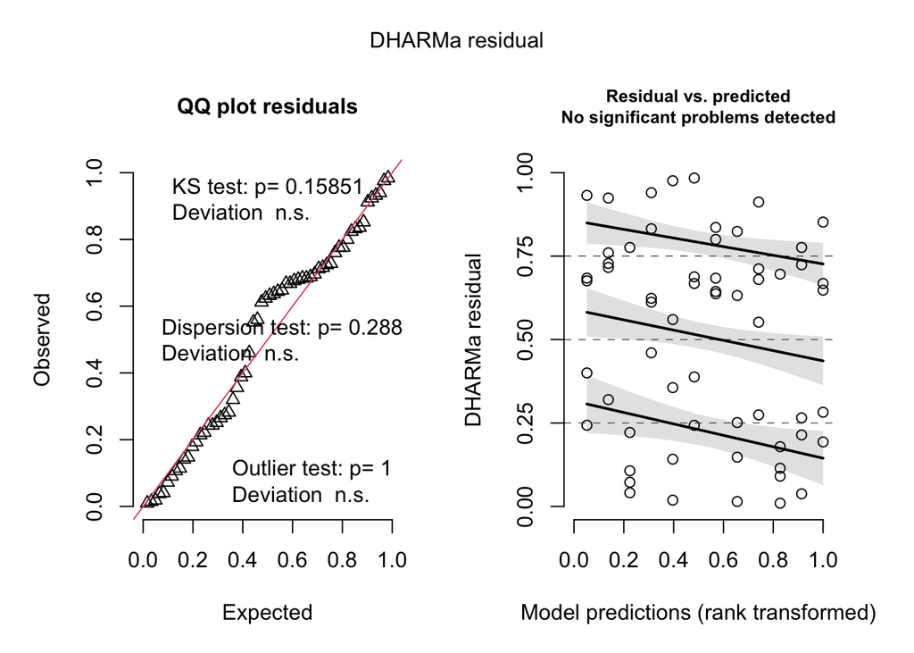

```r
sim_res_model <- simulateResiduals(fittedModel = model_zin_nbinom)
plot(sim_res_model) # no deviation or overdispersion detected!
```

```r
check_overdispersion(model_zin_nbinom) # ot overdispersed!
```

```
## # Overdispersion test
##
##  dispersion ratio = 0.600
##           p-value = 0.288
```

```
## No overdispersion detected.
```

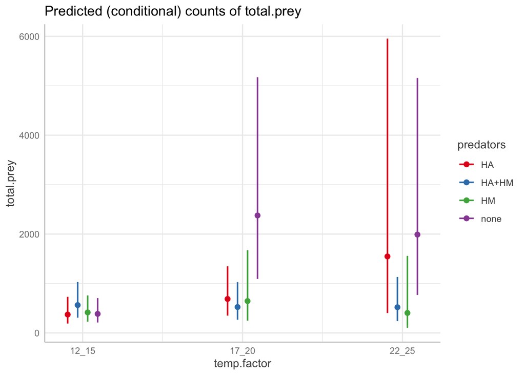

```r
plot(ggpredict(model_zin_nbinom, terms = c("temp.factor", "predators")))
```

appears zero-inflated negative binomial model is the best, run anova with others to confirm - from ggpredict - low prey survival at low temp, - either predator makes a big negative impact on survival at med temp - at high temp, seems like HA can’t survive, but prey can (b/c prey survives w/HA) - HM appears to still be effective predator at high temp, more resilient than HA

AIC to perform model selection against nbinom from above - Yes, model_zin_nbinom has the lowest AIC by far, both nbinom models better than poisson

```r
# use model_nb and model_full to compare against models with zero-inflation
anova(model_full, model_nb, model_zin_pois, model_zin_nbinom)
```

```
## Data: bugs
## Models:
## model_full: total.prey ~ temp.factor + predators + temp.factor * predators, zi=~0, disp=~1
## model_nb: total.prey ~ temp.factor + predators + temp.factor * predators, zi=~0, disp=~1
## model_zin_pois: total.prey ~ temp.factor + predators + temp.factor * predators, zi=~1, disp=~1
## model_zin_nbinom: total.prey ~ temp.factor + predators + temp.factor * predators, zi=~1, disp=~1
##                  Df   AIC   BIC   logLik deviance   Chisq Chi Df Pr(>Chisq)
## model_full       12 34028 34053 -17002.0    34004
## model_nb         13   734   762   -354.2      708 33295.5      1     <2e-16 ***
## model_zin_pois   13  6478  6505  -3226.1     6452     0.0      0          1
## model_zin_nbinom 14   674   703   -322.8      646  5806.6      1     <2e-16 ***
## ---
## Signif. codes:  0 '***' 0.001 '**' 0.01 '*' 0.05 '.' 0.1 ' ' 1
```

using best model, marginal likelihood ratio tests on predictors - stepwise remove terms

```r
# model_zin_nbinom from above
summary(model_zin_nbinom) # AIC 673.6
```

```
##  Family: nbinom2  ( log )
## Formula:
## total.prey ~ temp.factor + predators + temp.factor * predators
## Zero inflation:              ~1
## Data: bugs
##
##       AIC       BIC    logLik -2*log(L)  df.resid
##     673.6     702.9    -322.8     645.6        46
##
##
## Dispersion parameter for nbinom2 family (): 2.12
##
## Conditional model:
##                                 Estimate Std. Error z value Pr(>|z|)
## (Intercept)                      5.91754    0.34454  17.175   <2e-16 ***
## temp.factor17_20                 0.61443    0.48694   1.262   0.2070
## temp.factor22_25                 1.42652    0.76909   1.855   0.0636 .
## predatorsHA+HM                   0.41574    0.46205   0.900   0.3682
## predatorsHM                      0.10977    0.46219   0.238   0.8123
## predatorsnone                    0.03622    0.46223   0.078   0.9375
## temp.factor17_20:predatorsHA+HM -0.68765    0.67112  -1.025   0.3055
## temp.factor22_25:predatorsHA+HM -1.50727    0.91886  -1.640   0.1009
## temp.factor17_20:predatorsHM    -0.17328    0.75423  -0.230   0.8183
## temp.factor22_25:predatorsHM    -1.45253    1.07754  -1.348   0.1777
## temp.factor17_20:predatorsnone   1.20499    0.69970   1.722   0.0850 .
## temp.factor22_25:predatorsnone   0.21510    0.96061   0.224   0.8228
## ---
## Signif. codes:  0 '***' 0.001 '**' 0.01 '*' 0.05 '.' 0.1 ' ' 1
##
## Zero-inflation model:
##             Estimate Std. Error z value Pr(>|z|)
## (Intercept)  -0.6191     0.2707  -2.287   0.0222 *
## ---
## Signif. codes:  0 '***' 0.001 '**' 0.01 '*' 0.05 '.' 0.1 ' ' 1
```

```r
# model_no_temp
model_no_temp <- glmmTMB(total.prey ~ predators + temp.factor*predators,
                           data = bugs,
                            family = nbinom2,
                            ziformula = ~ 1)
summary(model_no_temp) # nothing sig, AIC 673.6, temp has no impact
```

```
##  Family: nbinom2  ( log )
## Formula:          total.prey ~ predators + temp.factor * predators
## Zero inflation:              ~1
## Data: bugs
##
##       AIC       BIC    logLik -2*log(L)  df.resid
##     673.6     702.9    -322.8     645.6        46
##
##
## Dispersion parameter for nbinom2 family (): 2.12
##
## Conditional model:
##                                 Estimate Std. Error z value Pr(>|z|)
## (Intercept)                      5.91754    0.34454  17.175   <2e-16 ***
## predatorsHA+HM                   0.41574    0.46205   0.900   0.3682
## predatorsHM                      0.10977    0.46219   0.238   0.8123
## predatorsnone                    0.03622    0.46223   0.078   0.9375
## temp.factor17_20                 0.61443    0.48694   1.262   0.2070
## temp.factor22_25                 1.42652    0.76909   1.855   0.0636 .
## predatorsHA+HM:temp.factor17_20 -0.68765    0.67112  -1.025   0.3055
## predatorsHM:temp.factor17_20    -0.17328    0.75423  -0.230   0.8183
## predatorsnone:temp.factor17_20   1.20499    0.69970   1.722   0.0850 .
## predatorsHA+HM:temp.factor22_25 -1.50727    0.91886  -1.640   0.1009
## predatorsHM:temp.factor22_25    -1.45253    1.07754  -1.348   0.1777
## predatorsnone:temp.factor22_25   0.21510    0.96061   0.224   0.8228
## ---
## Signif. codes:  0 '***' 0.001 '**' 0.01 '*' 0.05 '.' 0.1 ' ' 1
##
## Zero-inflation model:
##             Estimate Std. Error z value Pr(>|z|)
## (Intercept)  -0.6191     0.2707  -2.287   0.0222 *
## ---
## Signif. codes:  0 '***' 0.001 '**' 0.01 '*' 0.05 '.' 0.1 ' ' 1
```

```r
# model_no_pred
model_no_pred <- glmmTMB(total.prey ~ temp.factor + temp.factor*predators,
                            data = bugs,
                            family = nbinom2,
                            ziformula = ~ 1)
summary(model_no_pred) # nothing sig, AIC 673.6, pred has no impact
```

```
##  Family: nbinom2  ( log )
## Formula:          total.prey ~ temp.factor + temp.factor * predators
## Zero inflation:              ~1
## Data: bugs
##
##       AIC       BIC    logLik -2*log(L)  df.resid
##     673.6     702.9    -322.8     645.6        46
##
##
## Dispersion parameter for nbinom2 family (): 2.12
##
## Conditional model:
##                                 Estimate Std. Error z value Pr(>|z|)
## (Intercept)                      5.91754    0.34454  17.175   <2e-16 ***
## temp.factor17_20                 0.61443    0.48694   1.262   0.2070
## temp.factor22_25                 1.42652    0.76909   1.855   0.0636 .
## predatorsHA+HM                   0.41574    0.46205   0.900   0.3682
## predatorsHM                      0.10977    0.46219   0.238   0.8123
## predatorsnone                    0.03622    0.46223   0.078   0.9375
## temp.factor17_20:predatorsHA+HM -0.68765    0.67112  -1.025   0.3055
## temp.factor22_25:predatorsHA+HM -1.50727    0.91886  -1.640   0.1009
## temp.factor17_20:predatorsHM    -0.17328    0.75423  -0.230   0.8183
## temp.factor22_25:predatorsHM    -1.45253    1.07754  -1.348   0.1777
## temp.factor17_20:predatorsnone   1.20499    0.69970   1.722   0.0850 .
## temp.factor22_25:predatorsnone   0.21510    0.96061   0.224   0.8228
## ---
## Signif. codes:  0 '***' 0.001 '**' 0.01 '*' 0.05 '.' 0.1 ' ' 1
##
## Zero-inflation model:
##             Estimate Std. Error z value Pr(>|z|)
## (Intercept)  -0.6191     0.2707  -2.287   0.0222 *
## ---
## Signif. codes:  0 '***' 0.001 '**' 0.01 '*' 0.05 '.' 0.1 ' ' 1
```

```r
# model_no_int
model_no_int <- glmmTMB(total.prey ~ predators + temp.factor,
                            data = bugs,
                            family = nbinom2,
                            ziformula = ~ 1)
summary(model_no_int) # AIC 671.9, removing interaction improves model fit
```

```
##  Family: nbinom2  ( log )
## Formula:          total.prey ~ predators + temp.factor
## Zero inflation:              ~1
## Data: bugs
##
##       AIC       BIC    logLik -2*log(L)  df.resid
##     671.9     688.7    -328.0     655.9        52
##
##
## Dispersion parameter for nbinom2 family (): 1.68
##
## Conditional model:
##                  Estimate Std. Error z value Pr(>|z|)
## (Intercept)       6.01537    0.30217  19.907   <2e-16 ***
## predatorsHA+HM   -0.04954    0.34525  -0.143   0.8859
## predatorsHM      -0.10690    0.38447  -0.278   0.7810
## predatorsnone     0.62072    0.35749   1.736   0.0825 .
## temp.factor17_20  0.65117    0.29239   2.227   0.0259 *
## temp.factor22_25  0.69952    0.35454   1.973   0.0485 *
## ---
## Signif. codes:  0 '***' 0.001 '**' 0.01 '*' 0.05 '.' 0.1 ' ' 1
##
## Zero-inflation model:
##             Estimate Std. Error z value Pr(>|z|)
## (Intercept)  -0.6191     0.2707  -2.287   0.0222 *
## ---
## Signif. codes:  0 '***' 0.001 '**' 0.01 '*' 0.05 '.' 0.1 ' ' 1
```

```r
# sig effect of temp, higher survival at higher temperatures
```

anova to compare these candidate models against full zero-inflated negative binomial - the model without the interaction fits the best (lowest AIC)

```r
anova(model_zin_nbinom, model_no_temp, model_no_pred, model_no_int)
```

[output not shown]

how have results changed - the zero-inflated negative binomial fits much better than non zero-inflated models - the best fitting candidate model did not contain the interaction term - in this model we saw a significantly higher survival of prey in the medium and high temperature treatments compared to the low temperature treatment

#3.

doesn’t seem like big difference b/ween predator treatments

create new column, predator 0 or 1 (this will become a binomial)

```r
bugs <- bugs %>%
  mutate("predator_binary" = ifelse(predators == "none",0 , 1))
```

model_no_int was the highest performing, use this with new predator_binary

```r
# model_no_int_2
model_no_int_2 <- glmmTMB(total.prey ~ predator_binary + temp.factor,
                            data = bugs,
                            family = nbinom2,
                            ziformula = ~ 1)
summary(model_no_int_2) # AIC 668.0
```

```
##  Family: nbinom2  ( log )
## Formula:          total.prey ~ predator_binary + temp.factor
## Zero inflation:              ~1
## Data: bugs
##
##       AIC       BIC    logLik -2*log(L)  df.resid
##     668.0     680.6    -328.0     656.0        54
##
##
## Dispersion parameter for nbinom2 family (): 1.67
##
## Conditional model:
##                  Estimate Std. Error z value Pr(>|z|)
## (Intercept)        6.6249     0.3109  21.312   <2e-16 ***
## predator_binary   -0.6652     0.2949  -2.256   0.0241 *
## temp.factor17_20   0.6650     0.2874   2.314   0.0207 *
## temp.factor22_25   0.7167     0.3491   2.053   0.0401 *
## ---
## Signif. codes:  0 '***' 0.001 '**' 0.01 '*' 0.05 '.' 0.1 ' ' 1
##
## Zero-inflation model:
##             Estimate Std. Error z value Pr(>|z|)
## (Intercept)  -0.6191     0.2707  -2.287   0.0222 *
## ---
## Signif. codes:  0 '***' 0.001 '**' 0.01 '*' 0.05 '.' 0.1 ' ' 1
```

```r
# predators have a sig negative effect on survival
# temp has a sig positive effect on survival
```

```r
Anova(model_no_int_2) # temp.factor sig effect, predator_binary sig effect
```

```
## Analysis of Deviance Table (Type II Wald chisquare tests)
##
## Response: total.prey
##                  Chisq Df Pr(>Chisq)
## predator_binary 5.0899  1    0.02406 *
## temp.factor     7.0477  2    0.02949 *
## ---
## Signif. codes:  0 '***' 0.001 '**' 0.01 '*' 0.05 '.' 0.1 ' ' 1
```

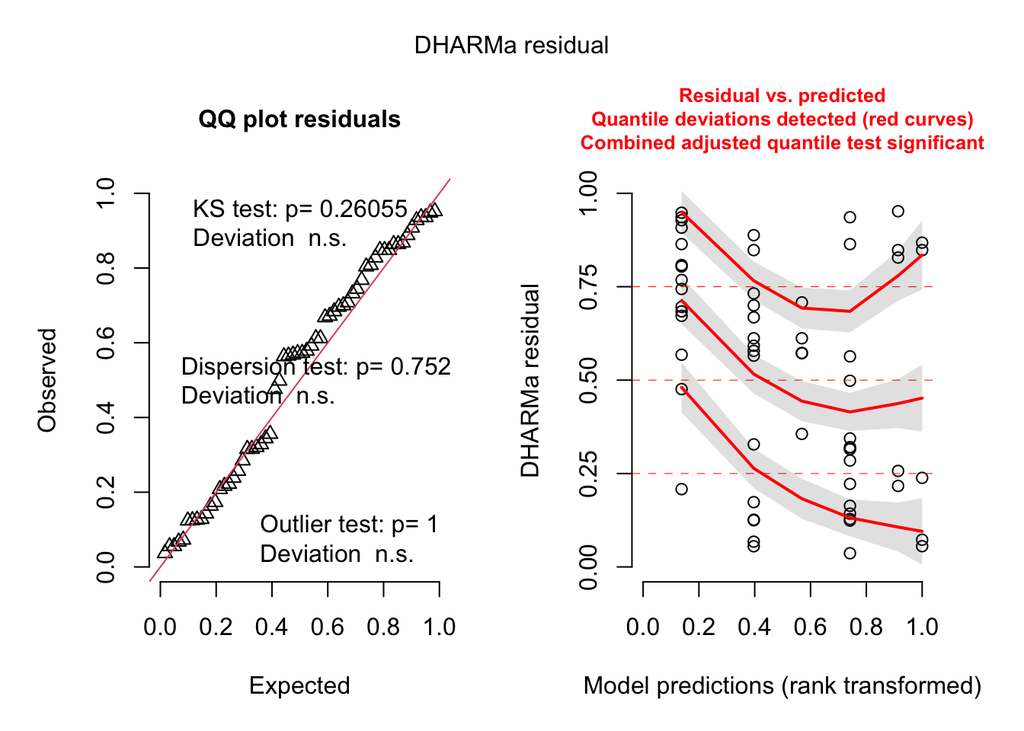

```r
sim_res_model <- simulateResiduals(fittedModel = model_no_int_2)
plot(sim_res_model) # deviation detected!
```

```r
check_overdispersion(model_no_int_2) # not overdispersed!
```

```
## # Overdispersion test
##
##  dispersion ratio = 0.795
##           p-value = 0.752
```

```
## No overdispersion detected.
```

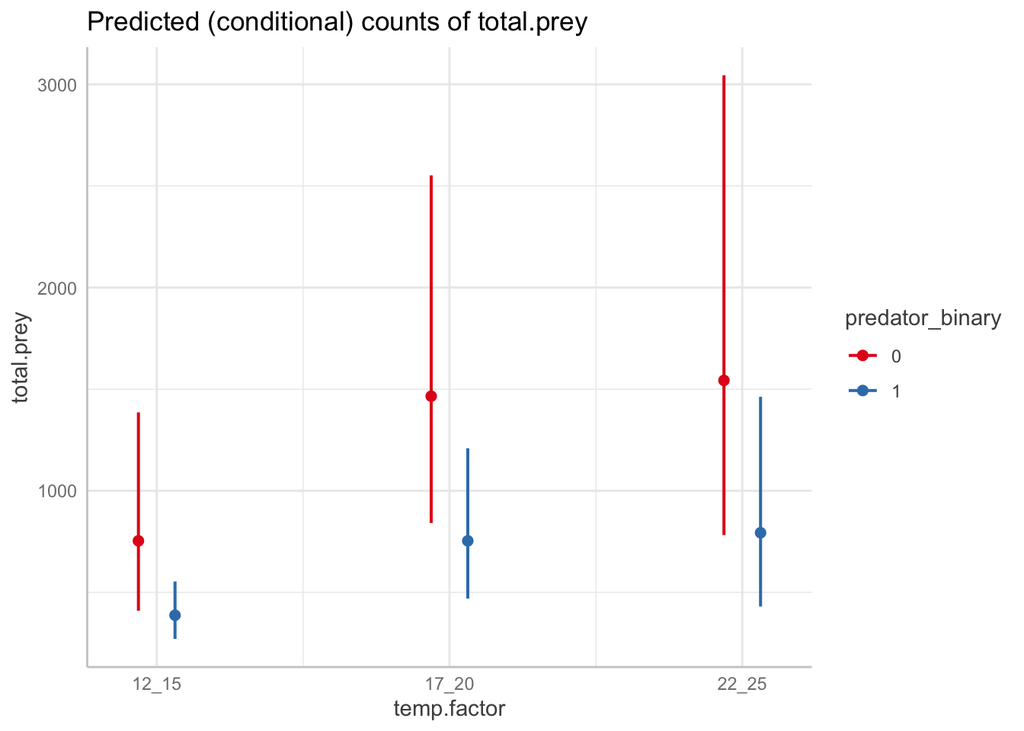

```r
plot(ggpredict(model_no_int_2, terms = c("temp.factor", "predator_binary")))
```

we now see that both the presence of predators, and the temperature have significant effects on survival - these patterns are similar to what I saw previously, but the effect of each variable is a bit easier to see now.

#4.

zeros could vary across experimental treatments - this makes sense, maybe at lower temperatures more things die?

use an appropriate zero-inflated model and allow extra zeros to vary w/ temp, pred, interaction

```r
# use model_no_int_2 as base, this was the best fitting model (lowest AIC)
model_no_int_3 <- glmmTMB(total.prey ~ temp.factor + predator_binary,
                            data = bugs,
                            family = nbinom2,
                            ziformula = ~ temp.factor*predator_binary)
summary(model_no_int_3)
```

```
##  Family: nbinom2  ( log )
## Formula:          total.prey ~ temp.factor + predator_binary
## Zero inflation:              ~temp.factor * predator_binary
## Data: bugs
##
##       AIC       BIC    logLik -2*log(L)  df.resid
##     659.3     682.3    -318.6     637.3        49
##
##
## Dispersion parameter for nbinom2 family (): 1.67
##
## Conditional model:
##                  Estimate Std. Error z value Pr(>|z|)
## (Intercept)        6.6248     0.3109  21.309   <2e-16 ***
## temp.factor17_20   0.6651     0.2875   2.314   0.0207 *
## temp.factor22_25   0.7169     0.3491   2.053   0.0400 *
## predator_binary   -0.6652     0.2949  -2.256   0.0241 *
## ---
## Signif. codes:  0 '***' 0.001 '**' 0.01 '*' 0.05 '.' 0.1 ' ' 1
##
## Zero-inflation model:
##                                  Estimate Std. Error z value Pr(>|z|)
## (Intercept)                        -19.08    6211.28  -0.003    0.998
## temp.factor17_20                    18.67    6211.28   0.003    0.998
## temp.factor22_25                    19.48    6211.28   0.003    0.997
## predator_binary                     16.44    6211.28   0.003    0.998
## temp.factor17_20:predator_binary   -16.72    6211.28  -0.003    0.998
## temp.factor22_25:predator_binary   -16.15    6211.28  -0.003    0.998
```

```r
model_no_int_4 <- glmmTMB(total.prey ~ temp.factor + predator_binary,
                            data = bugs,
                            family = nbinom2,
                            ziformula = ~ temp.factor)
summary(model_no_int_4) # best fit, AIC 654
```

```
##  Family: nbinom2  ( log )
## Formula:          total.prey ~ temp.factor + predator_binary
## Zero inflation:              ~temp.factor
## Data: bugs
##
##       AIC       BIC    logLik -2*log(L)  df.resid
##     654.0     670.8    -319.0     638.0        52
##
##
## Dispersion parameter for nbinom2 family (): 1.67
##
## Conditional model:
##                  Estimate Std. Error z value Pr(>|z|)
## (Intercept)        6.6248     0.3109  21.307   <2e-16 ***
## temp.factor17_20   0.6651     0.2875   2.313   0.0207 *
## temp.factor22_25   0.7169     0.3492   2.053   0.0400 *
## predator_binary   -0.6652     0.2949  -2.256   0.0241 *
## ---
## Signif. codes:  0 '***' 0.001 '**' 0.01 '*' 0.05 '.' 0.1 ' ' 1
##
## Zero-inflation model:
##                  Estimate Std. Error z value Pr(>|z|)
## (Intercept)        -2.947      1.028  -2.866  0.00416 **
## temp.factor17_20    2.328      1.130   2.060  0.03942 *
## temp.factor22_25    3.566      1.130   3.156  0.00160 **
## ---
## Signif. codes:  0 '***' 0.001 '**' 0.01 '*' 0.05 '.' 0.1 ' ' 1
```

```r
model_no_int_5 <- glmmTMB(total.prey ~ temp.factor + predator_binary,
                            data = bugs,
                            family = nbinom2,
                            ziformula = ~ predator_binary)
summary(model_no_int_5)
```

```
##  Family: nbinom2  ( log )
## Formula:          total.prey ~ temp.factor + predator_binary
## Zero inflation:              ~predator_binary
## Data: bugs
##
##       AIC       BIC    logLik -2*log(L)  df.resid
##     670.0     684.6    -328.0     656.0        53
##
##
## Dispersion parameter for nbinom2 family (): 1.67
##
## Conditional model:
##                  Estimate Std. Error z value Pr(>|z|)
## (Intercept)        6.6249     0.3109  21.312   <2e-16 ***
## temp.factor17_20   0.6650     0.2874   2.314   0.0207 *
## temp.factor22_25   0.7167     0.3491   2.053   0.0401 *
## predator_binary   -0.6652     0.2949  -2.256   0.0241 *
## ---
## Signif. codes:  0 '***' 0.001 '**' 0.01 '*' 0.05 '.' 0.1 ' ' 1
##
## Zero-inflation model:
##                 Estimate Std. Error z value Pr(>|z|)
## (Intercept)     -0.69318    0.54774  -1.266    0.206
## predator_binary  0.09837    0.63009   0.156    0.876
```

likelihood ratio tests between these models - allowing zero inflation to change based on temperature has the best fit

```r
anova(model_no_int_3, model_no_int_4, model_no_int_5)
```

```
## Data: bugs
## Models:
## model_no_int_5: total.prey ~ temp.factor + predator_binary, zi=~predator_binary, disp=~1
## model_no_int_4: total.prey ~ temp.factor + predator_binary, zi=~temp.factor, disp=~1
## model_no_int_3: total.prey ~ temp.factor + predator_binary, zi=~temp.factor * predator_binary, disp=~1
##                Df    AIC    BIC  logLik deviance   Chisq Chi Df Pr(>Chisq)
## model_no_int_5  7 669.96 684.62 -327.98   655.96
## model_no_int_4  8 654.03 670.78 -319.01   638.03 17.9356      1  2.285e-05 ***
## model_no_int_3 11 659.29 682.33 -318.64   637.29  0.7363      3     0.8646
## ---
## Signif. codes:  0 '***' 0.001 '**' 0.01 '*' 0.05 '.' 0.1 ' ' 1
```

```r
# lowest AIC is model_no_int_4

# run diagnostics on model_no_int_4
Anova(model_no_int_4) # temp.factor sig effect, predator_binary sig effect
```

```
## Analysis of Deviance Table (Type II Wald chisquare tests)
##
## Response: total.prey
##                  Chisq Df Pr(>Chisq)
## temp.factor     7.0471  2    0.02949 *
## predator_binary 5.0881  1    0.02409 *
## ---
## Signif. codes:  0 '***' 0.001 '**' 0.01 '*' 0.05 '.' 0.1 ' ' 1
```

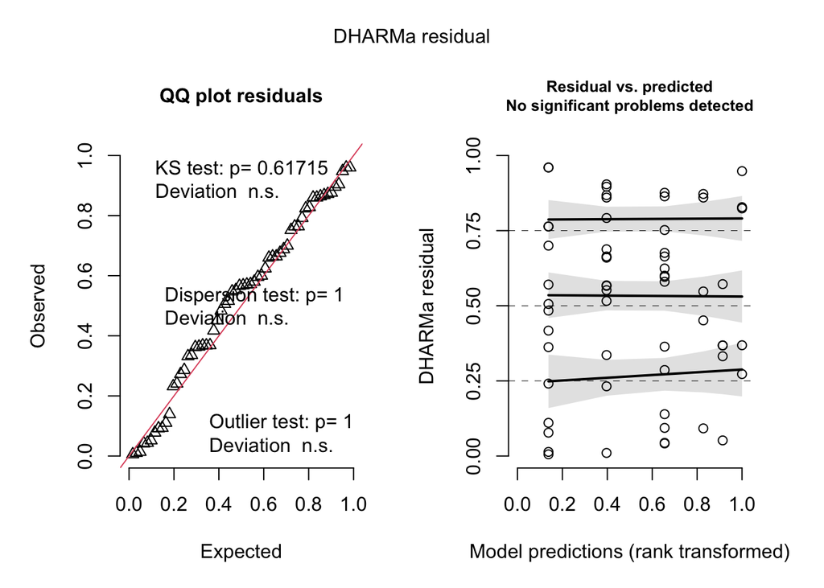

```r
sim_res_model <- simulateResiduals(fittedModel = model_no_int_4)
plot(sim_res_model) # no deviation detected!
```

```r
check_overdispersion(model_no_int_4) # not overdispersed!
```

```
## # Overdispersion test
##
##  dispersion ratio = 0.850
##           p-value =     1
```

```
## No overdispersion detected.
```

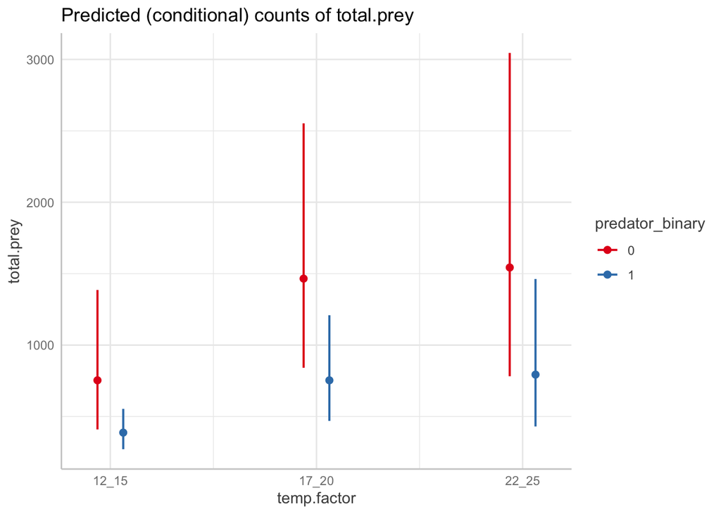

```r
plot(ggpredict(model_no_int_4, terms = c("temp.factor", "predator_binary")))
```